[figure not shown]

# DNA methylation: Array analysis

Paul Ruiz, Divya Mehta

2025-07-17

## Overview

This workshop provides an introduction to DNA methylation analysis using the [`minfi`](https://www.bioconductor.org/packages/devel/bioc/manuals/minfi/man/minfi.pdf) package in R. It covers the following key steps:

1. **Data Import**: Loading raw methylation data from IDAT files.
2. **Exploration**: Generating control plots to assess data quality.
3. **Quality Control**: Assessing the quality of the data using control plots and metrics.
4. **Normalization**: Applying functional normalization to adjust for technical biases.
5. **Filtering**: removing chromosome X and Y probes, and probes with low detection p-values, cross-reactive probes and SNP probes.

### Dataset

The following analysis is based on **DNA methylation** data obtained from the [GEO Series GSE246337](https://www.ncbi.nlm.nih.gov/geo/query/acc.cgi?acc=GSE246337). The dataset includes genome-wide methylation profiles generated using the **Illumina Infinium MethylationEPIC v2.0 array**, derived from blood samples.

A total of **50 samples** were selected for this analysis. Sample-level metadata was extracted and cleaned from the provided *Series Matrix* text file.

*Dataset Summary*

- **Organism:** *Homo sapiens*
- **Sample size:** 500 individuals
- **Access:** [NCBI GEO - GSE246337](https://www.ncbi.nlm.nih.gov/geo/query/acc.cgi?acc=GSE246337)
- **Article:** [bioRxiv (2024)](https://www.biorxiv.org/content/10.1101/2024.05.30.596713v1.full)

### Aim

The aim of this analysis is to identify differentially methylated CpG sites associated with **Age**, while adjusting for biological covariates including **Sex, Race, and estimated cell-type proportions**. This is achieved using a linear model framework from the package [`limma`](https://bioconductor.org/packages/release/bioc/manuals/limma/man/limma.pdf).

## Libraries

The following code installs and loads the required packages for this analysis.

```r
# # Install and load required packages
#
# instalload <- function(cran=NULL, bioc=NULL) {
#   pkgs_cran <- cran[!(cran %in% installed.packages()[, "Package"])]
#   if (length(pkgs_cran) > 0) {
#     install.packages(pkgs_cran, dependencies = T)
#   }
#
#   if (!requireNamespace("BiocManager", quietly = T))
#           install.packages("BiocManager")
#   pkgs_bioc <- bioc[!(bioc %in% installed.packages()[, "Package"])]
#   if (length(pkgs_bioc) > 0) {
#     BiocManager::install(pkgs_bioc, ask = F)
#   }
#
#   pkgs <- c(cran, bioc)
#   invisible(lapply(pkgs, require, character.only = T))
#
#   cat("Packages are installed and loaded successfully.\n")
# }
#
# # CRAN & Bioconductor packages
# cran <- c("ENmix", "ggplot2", "gridExtra", "RColorBrewer",
#           "stringr", "Gviz", "rstudioapi", "knitr", "qqman")
#
# bioc <- c("minfi",
#           "IlluminaHumanMethylationEPICv2anno.20a1.hg38",
#           "IlluminaHumanMethylationEPICv2manifest",
#           "FlowSorted.Blood.EPIC", "limma")
#
# instalload(cran, bioc)
```

## Working Directory

The following code sets the working directory to the location of this R Markdown file.

```r
# setwd(dirname(getSourceEditorContext()$path))
# print(getwd())
```

# Load Data

### Load sample data

```r
# # Sample data
# targets <- read.csv("data/pheno.csv")
# str(targets)
```

In our analysis, we focus on **Age** as the outcome and for now we can consider as covariates **Sex** and **Race**. Variables as **GID**, **Description**, and **Tissue** are used for tracking and data merging, but are not directly included in the statistical model. **SID** and **Basename** are identifiers for each sample, ensuring we can link the metadata to the raw data files. **Tissue** is constant across samples, so it does not need to be included in the model.

### Load methylation data

```r
# # Load the raw methylation data from the idat files
# RGSet <- read.metharray.exp(base="data/idats",
#                             targets=targets,
#                             extended=F,
#                             recursive=F,
#                             verbose=F)
#
# str(RGSet)
```

- **50 samples** (columns) with associated phenotypic information (sex, age, race, others)
- **Over 1.1 million probes** (rows) representing individual CpG sites

This object will be used as input for exploration, quality control and preprocessing steps.

## Exploration

This section is based on the **Control table** used by [Illumina](https://support-docs.illumina.com/ARR/Inf-MSA/Content/ARR/MSA/ControlBeadTypeTable.htm) to explore expected performance of the assay (Figure 1, 2).

We will generate control plots to assess the quality of the data and identify any potential issues with the samples using the [`ENmix`](https://www.bioconductor.org/packages/devel/bioc/manuals/ENmix/man/ENmix.pdf) package. The issues can be related to the sample preparation, bisulfite conversion, hybridization, or other steps in the methylation assay process.

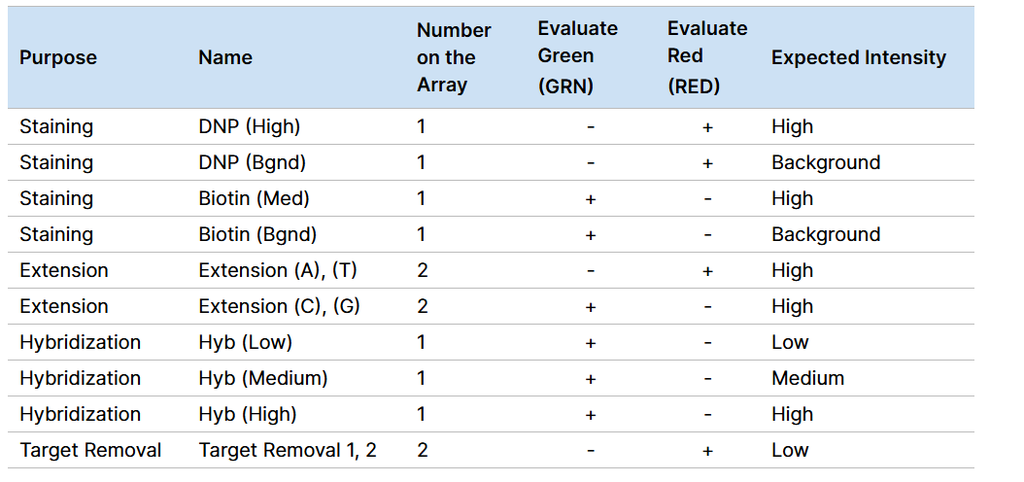

Figure 1. Independent Controls. Source: Illumina. “Control Bead Type Table.” Illumina Support Documentation, https://support-docs.illumina.com/ARR/Inf-MSA/Content/ARR/MSA/ControlBeadTypeTable.htm. Accessed 17 July 2025. Assay

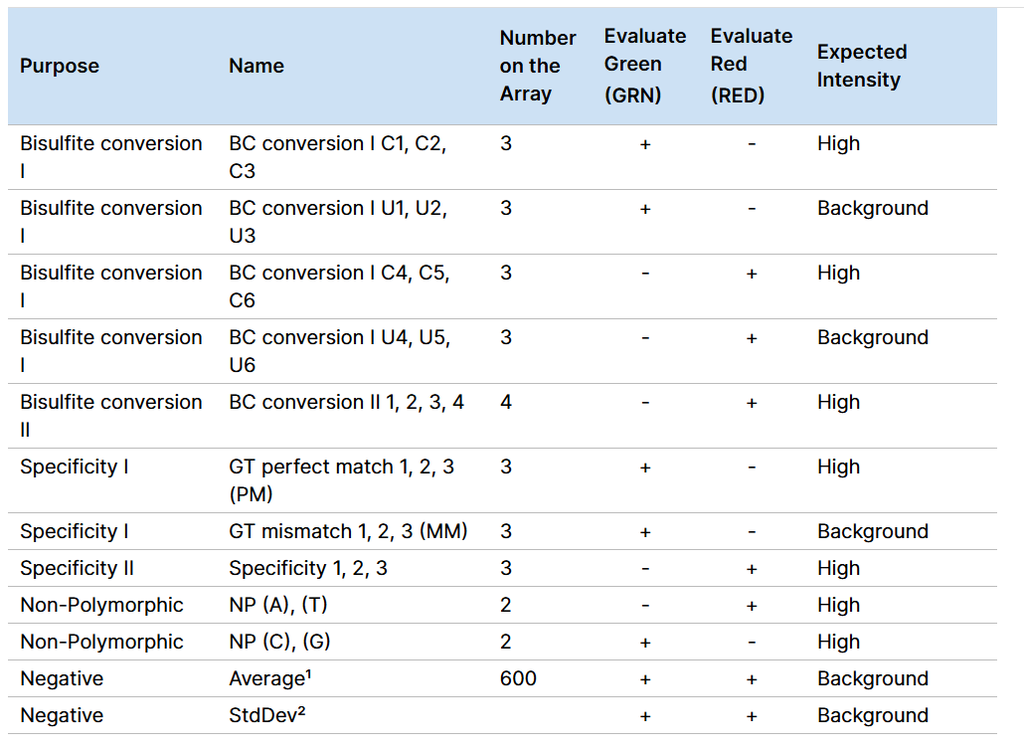

Figure 2. DependantControls. Source: Illumina. “Control Bead Type Table.” Illumina Support Documentation, https://support-docs.illumina.com/ARR/Inf-MSA/Content/ARR/MSA/ControlBeadTypeTable.htm. Accessed 17 July 2025. Assay

### Control probes plot using ENmix

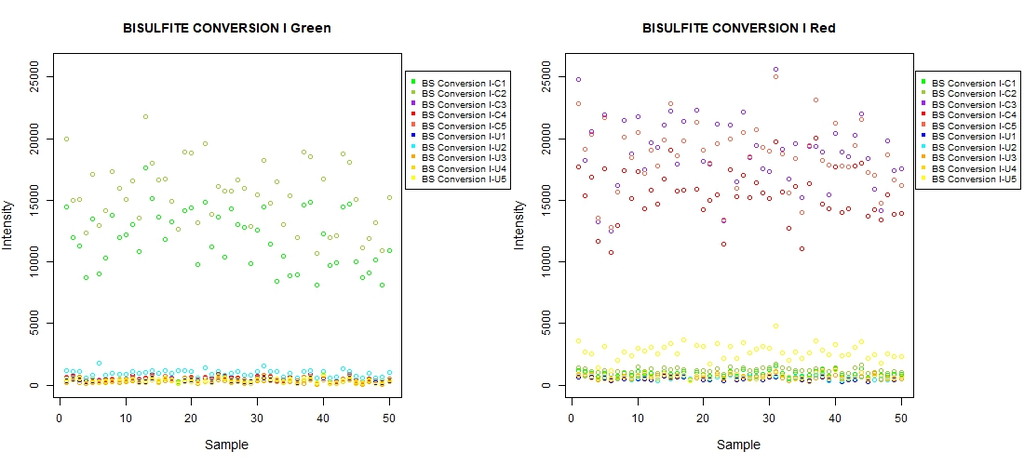

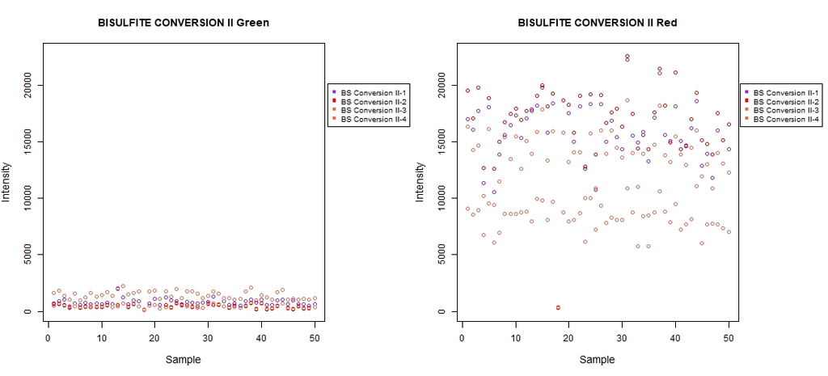

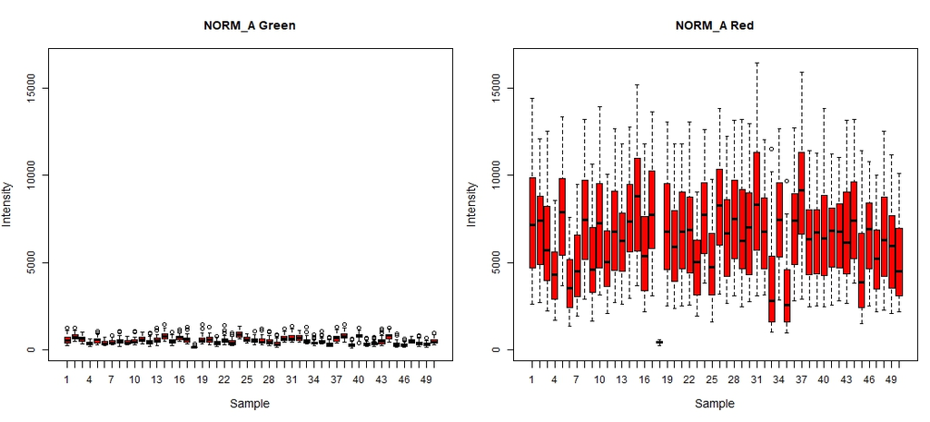

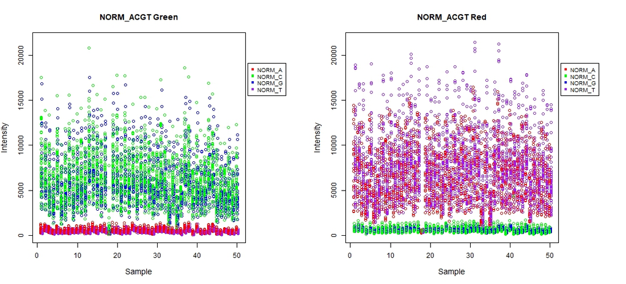

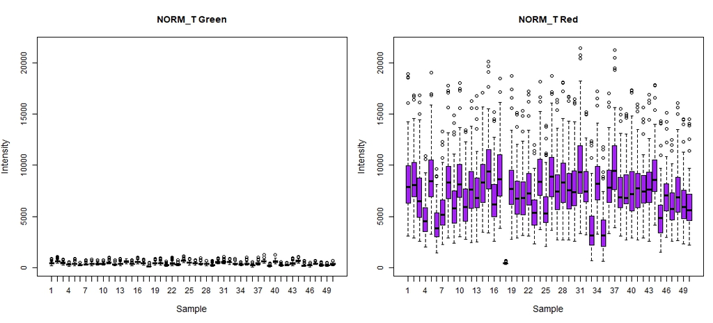

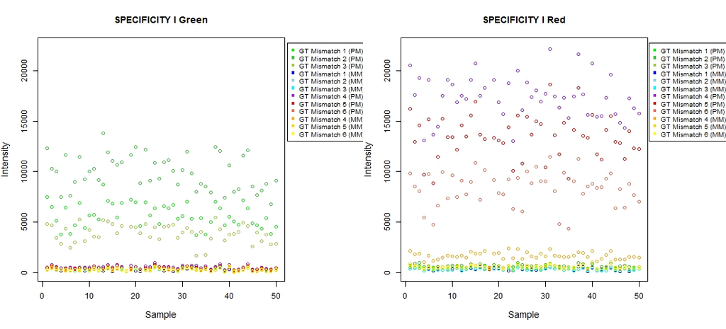

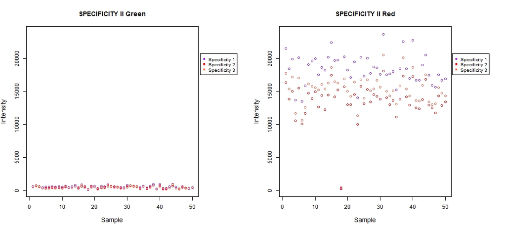

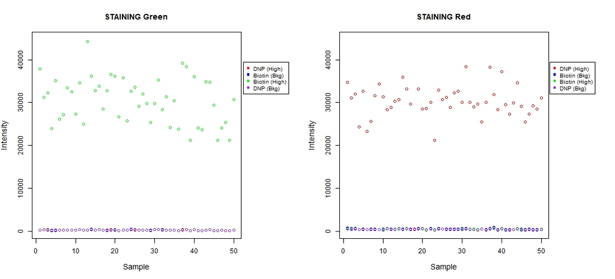

```r
# # Generate ENmix control plots
# plotCtrl(RGSet)
#
# # Create a directory for ENmix control plots
# if (!dir.exists("figures/enMix")) {
#   dir.create("figures/enMix", recursive = TRUE)
# }
#
# # Move all .jpg control plots to the target folder
# jpgFiles <- list.files(pattern = "\\.jpg$")
# file.rename(from = jpgFiles,
#             to   = file.path("figures/enMix", jpgFiles))
```

# Minfi

When working with DNA methylation data in **minfi**, the data goes through several transformation steps, and each step is stored in a specific type of object (Figure 3). It is important to understand how these object types are connected.

The process begins by reading **IDAT files**, which are stored in an object called an **RGChannelSet**. This raw data is then processed using a **preprocessing function**, which converts it into a **MethylSet**.

From there, two additional functions — **`ratioConvert()`** and **`mapToGenome()`** are used to transform the MethylSet into a **GenomicRatioSet**, which is ready for downstream analysis.

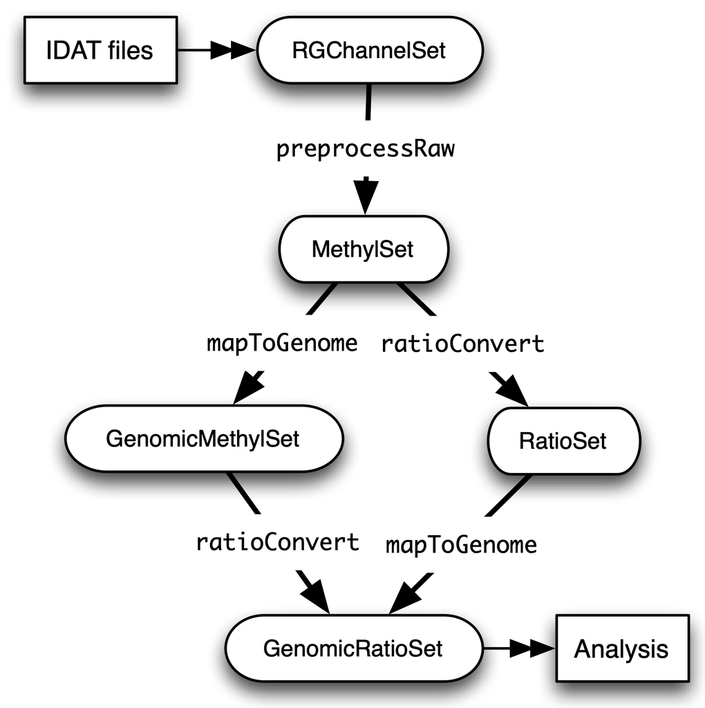

Figure 3. Flowchart of the different *minfi class objects. Source: NBIS (National Bioinformatics Infrastructure Sweden). (n.d.). Methylation array tutorial. NBIS Workshop on Epigenomics. Retrieved July 17, 2025, from https://nbis-workshop-epigenomics.readthedocs.io/en/latest/content/tutorials/methylationArray/Array_Tutorial.html